# Check - IN

# LDA for negative tweets

```python
import pandas as pd
from sklearn.feature_extraction.text import CountVectorizer
from sklearn.decomposition import LatentDirichletAllocation

from sklearn.feature_extraction import text

# Read the negative reviews data
negative_reviews = pd.read_csv("D:\\Internship Progress\\WEEK3 new updated\\WEEK3\\Hospitality\\check-in.csv")

# Combine reviews into a list
reviews = negative_reviews['tweet'].tolist()

# Create a custom stop words list if needed
custom_stop_words = ["read", "good", "disney", "yorker", "day", "didn", "stay", "great", "check", "booked", "like", "die", "told", "friendly", "clean", "sehr", "das", "zimmer", "und", "nice", "did", "was", "really", "safe", "walk", "close", "got"]

# Add your custom stop words to this list
stop_words = text.ENGLISH_STOP_WORDS.union(custom_stop_words)

# Vectorize the text data
vectorizer = CountVectorizer(max_df=0.95, min_df=2, stop_words=stop_words)
X = vectorizer.fit_transform(reviews)

# Apply LDA for topic modeling
num_topics = 5
lda = LatentDirichletAllocation(n_components=num_topics, random_state=42)
lda.fit(X)

# Extract top words for each topic
feature_names = vectorizer.get_feature_names_out()
topics = []
for topic_idx, topic in enumerate(lda.components_):
    top_words_idx = topic.argsort()[-10:]
    top_words = [feature_names[i] for i in top_words_idx]
    topics.append(top_words)

# Print the top words for each topic (possible reasons for positive reviews)


for i, topic in enumerate(topics):
    print(f"Topic {i + 1}: {', '.join(topic)}")
```

```
Topic 1: service, counter, left, bag, inside, sent, dont, stuck, disappointing, problem
Topic 2: management, baggage, counters, print, lost, security, counter, queue, indigo, flight
Topic 3: excess, worst, priority, staff, baggage, bag, left, stuck, passengers, counter
Topic 4: bag, akasa, boarding, baggage, luggage, akasaair, counter, experience, staff, checkin
Topic 5: open, unacceptable, making, counter, people, mumbai, staff, ticket, flight, amp
```

# Observation on negative tweets

- ### Negative experiences with baggage handling were commonly reported, including lost or delayed baggage, long queues at the counters, and rude or unhelpful staff.
- ### Passengers also expressed dissatisfaction with the cost of excess baggage charges and the lack of priority handling for priority passengers.
- ### Overall, the feedback suggests that there is room for improvement in the baggage handling process at all of the airlines and airports mentioned in the topics. ## Recommendations:
- ### Airlines and airports should review their baggage handling procedures and staff training to ensure that all passengers have a smooth and efficient experience.
- ### Airlines should be more transparent about baggage charges and priority handling policies.
- ### Airlines and airports should work to reduce wait times at the counters by increasing staff and improving efficiency.
- ### Staff should be more helpful and responsive to passenger concerns.

# Word Cloud for negative tweets

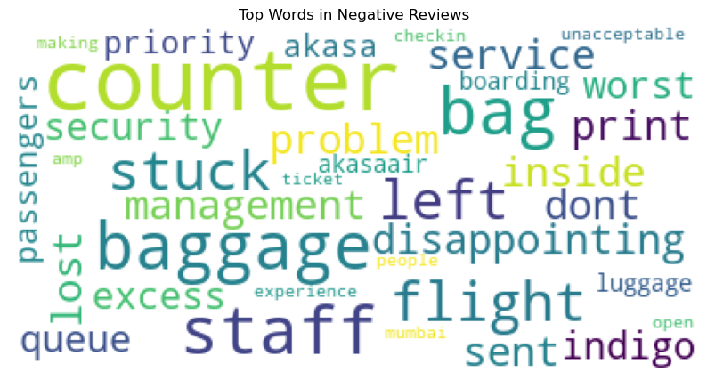

```python
import matplotlib.pyplot as plt
from wordcloud import WordCloud

# Create a word cloud object
wc = WordCloud(background_color="white", max_font_size=50)

# Check the type of the topics variable
if isinstance(topics, list):
    # Convert the topics variable to a list of strings
    topics = [" ".join(topic) for topic in topics]

# Generate the word cloud
wc.generate(" ".join(topics))

# Plot the word cloud
plt.figure(figsize=(10, 10))
plt.imshow(wc)
plt.axis("off")
plt.title("Top Words in Negative Reviews")
plt.show()
```